# Finding Clusters in Networks

SPOR Cluster · TU Eindhoven

Leto Peel

2026-06-02

[interactive chart not shown]

### Finding Clusters in Networks

*fundamental limits · systematic biases · principled inference*

Leto Peel

**Maastricht University**

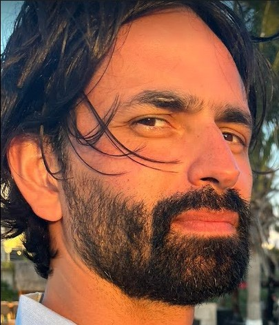

**MEng** Engineering Mathematics · Bristol

**BAE Systems** — maritime anomaly detection, fault diagnosis, robotics

**EngD** Computer Science · UCL

**Postdoc** Geomatics · UCL

**Postdoc** BioFrontiers · Colorado

**Postdoc** Applied Maths · UCLouvain

**Now** DAD department · SBE · Maastricht

*(and publishes in physics journals)*

Who am I? = *an undisciplined scientist*

## What is community detection?

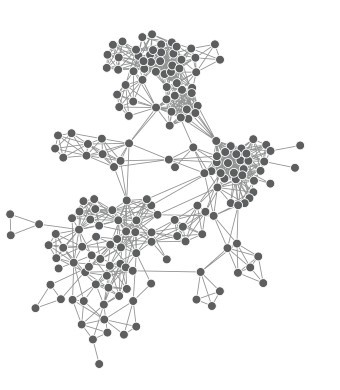

→

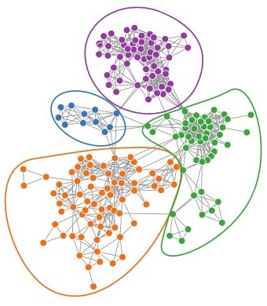

Given a graph, identify groups of nodes with **similar connectivity patterns** — no labels, no coordinates.

## Communities often reflect real structure

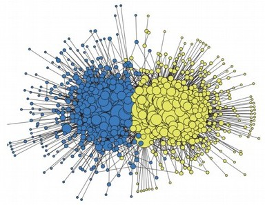

US political blogs

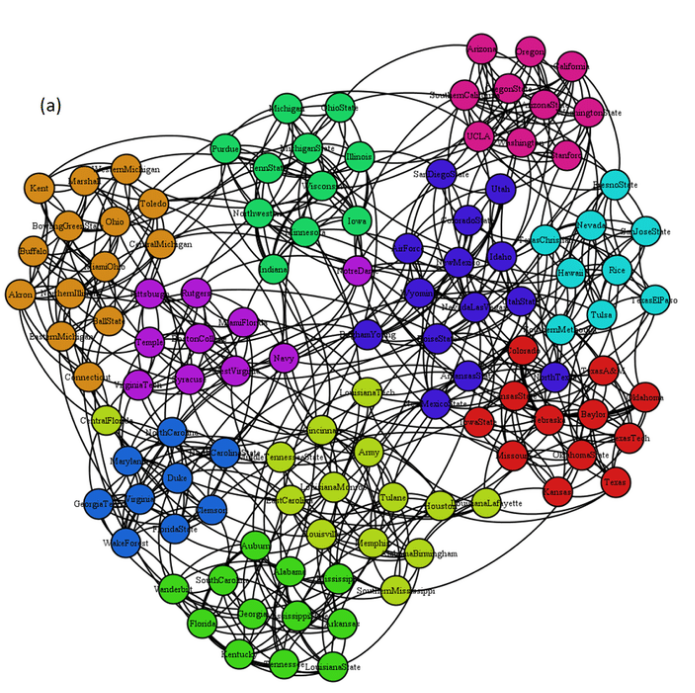

American college football

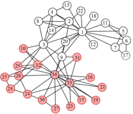

Karate club

Structure inferred from edges alone often corresponds to some property or function of the nodes.

## When can we reliably know something about network structure?

**①** Are these the communities we are looking for?

**②** When is structure detectable at all?

**③** What if communities have communities?

**④** Does size matter?

**⑤** Does going higher-order actually change anything?

## When can we reliably know something about network structure?

**①** Are these the communities we are looking for?

**②** When is structure detectable at all?

**③** What if communities have communities?

**④** Does size matter?

**⑤** Does going higher-order actually change anything?

## Clustering

[interactive chart not shown]

## “Cluster” these objects

## “Cluster” these objects

Red

Not red

## “Cluster” these objects

Cannot fly

Can fly

## “Cluster” these objects

Transport

Not transport

## “Cluster” these objects

Not alive

Alive

Each partition is equally valid — the “correct” grouping depends entirely on what question you are asking.

## Which partition is the right one?

Real networks come with metadata — political affiliation, department, species, role.

The temptation: run community detection, check that the communities match the labels.

**High agreement → the method works. ✓**

“Do you think that’s the true partition you’re detecting?”

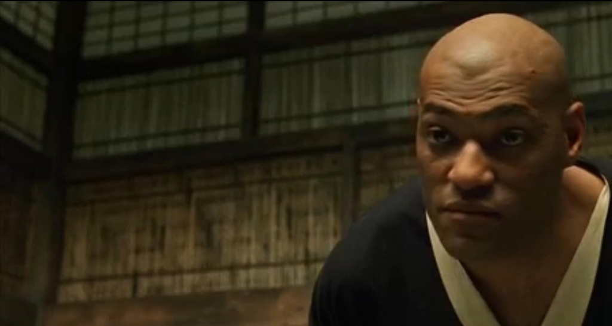

## When communities ≠ metadata

**(i)** the metadata is unrelated to network structure

**(ii)** communities and metadata capture *different* aspects of structure

**(iii)** the network has no community structure

**(iv)** the algorithm performed poorly

This is the only reason usually considered

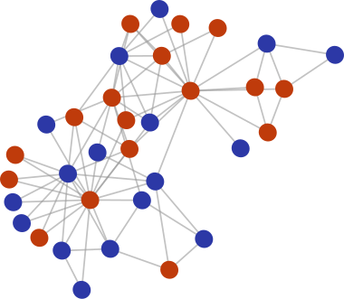

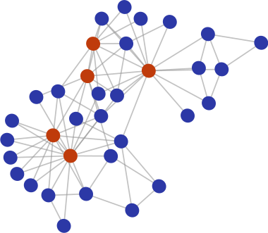

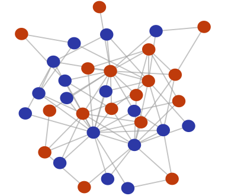

[figure not shown]

## The Karate Club

Peel, Larremore & Clauset · *Science Advances* (2017)

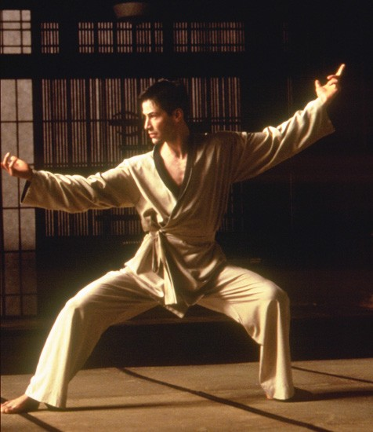

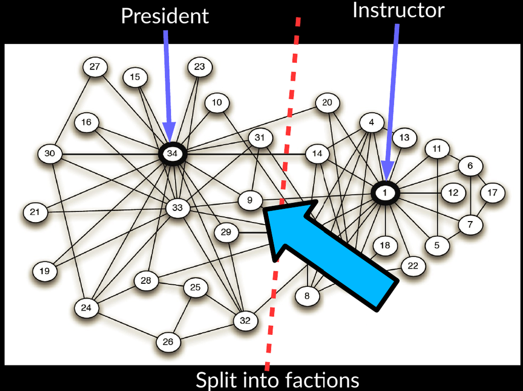

Node 9 sits on the wrong side of the faction boundary.

Why? He was **three weeks away from his black belt test** when the club split.

Joining the officers’ club would have meant starting over as a white belt.

Zachary · *Journal of Anthropological Research* (1977)

The network encoded something real about node 9 — just not the faction split.

## You only see what you look for

Adamic & Glance · *LinkKDD* (2005) Peixoto · *Phys. Rev. X* (2014)

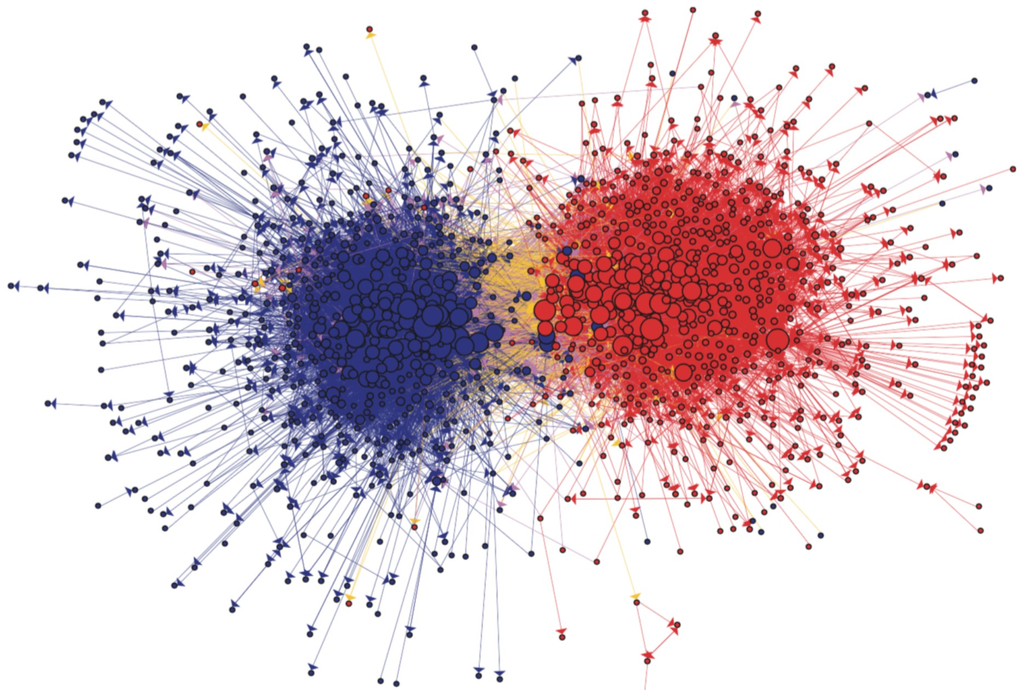

Two communities

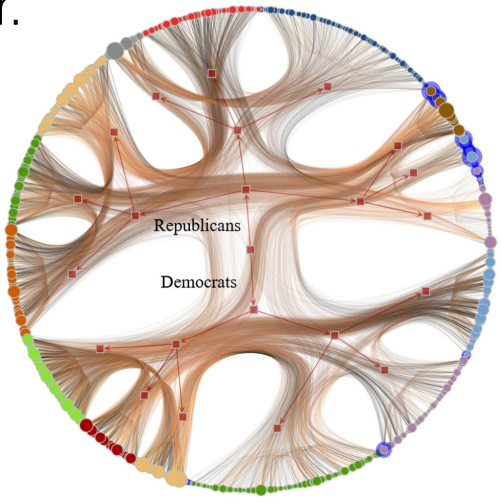

Hierarchical structure — same network

US politics is more than two opposing views. The partition you find is determined by the model you impose.

## Algorithms will always find something

[interactive chart not shown]

Same algorithm.

Random graph.

Still finds clusters.

Any algorithm finds communities in a network.

The question is not *whether* a partition exists — it is whether there is *evidence* for one **in the graph**.

## Supervised vs unsupervised

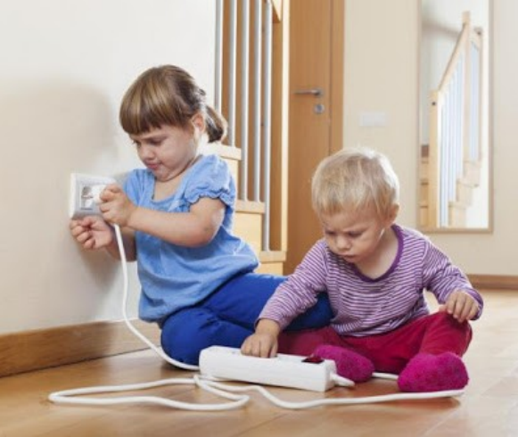

The supervised learner **doesn’t know much**.

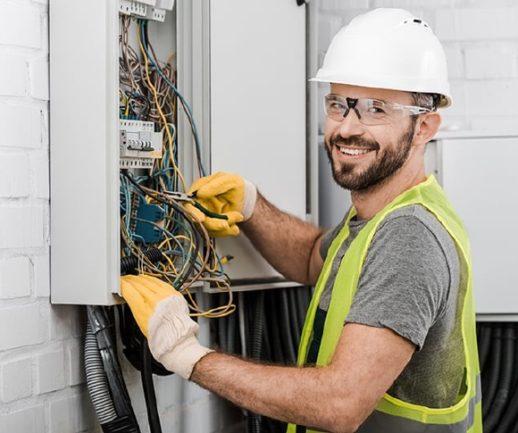

The unsupervised learner **already knows what it’s doing**.

Community detection is **unsupervised**. The algorithm’s definition of “community” was fixed before it saw your data.

Comparing its output to metadata tests the *relationship between topology and that label* — not the validity of the method.

[figure not shown]

**Take-home 1:** Metadata agreement is not evidence of structure — the model is.

## When can we reliably know something about network structure?

**①** Are these the communities we are looking for?

**②** When is structure detectable at all?

**③** What if communities have communities?

**④** Does size matter?

**⑤** Does going higher-order actually change anything?

## The stochastic block model

mixing matrix

adjacency matrix

[interactive chart not shown]

*P*(A<sub>ij</sub> = 1) = Ω<sub>σ<sub>i</sub>σ<sub>j</sub></sub> — edge probability depends only on community membership

## From belief propagation to a spectral operator

① Belief propagation is exact on trees: messages μ<sub>i→j</sub> passed along directed edges, avoids double-counting. Decelle et al. · Physical Review E (2011)]

② Sparse SBMs are locally tree-like — so BP ≈ optimal at the limit.

③ Linearizing BP gives a matrix — the *non-backtracking operator* **NB**: indexed by directed edges. Krzakala et al. · PNAS (2013)

④ NB is 2m×2m — inconvenient. Project back to *n* nodes and you get the **Bethe Hessian**: symmetric, *n×n*. Saade, Krzakala & Zdeborová · NeurIPS (2014)

[figure not shown]

B<sub>η</sub> = (η² − 1) I + D − η A

■ identity ■ degree ■ adjacency

symmetric · n×n · follows from BP → NB fixed points

[interactive chart not shown]

## The Bethe Hessian encodes the NB spectrum

[figure not shown]

Kesten–Stigum threshold

SNR = (d<sub>in</sub> − d<sub>out</sub>)<sup>2</sup> ⁄ (d<sub>in</sub> + d<sub>out</sub>) > 1

non-backtracking spectrum

[figure not shown]

eigenvalues of B<sub>η</sub>

[figure not shown]

When η hits an NB eigenvalue λ, B<sub>η</sub> gains a zero eigenvalue whose eigenvector is the pooled NB vector μ. Sweep η down: each outlier you pass turns one eigenvalue of B<sub>η</sub> negative.

[figure not shown]

**Take-home 2:** Detection has a hard mathematical limit. BP and the Bethe Hessian reach it.

## When can we reliably know something about network structure?

**①** Are these the communities we are looking for?

**②** When is structure detectable at all?

**③** What if communities have communities?

**④** Does size matter?

**⑤** Does going higher-order actually change anything?

## A hierarchical method always finds a hierarchy

Schaub, Li & Peel · *Phys. Rev. E* (2023)

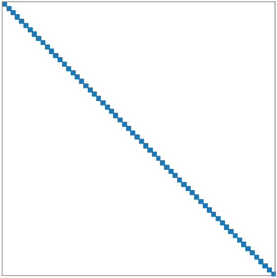

→

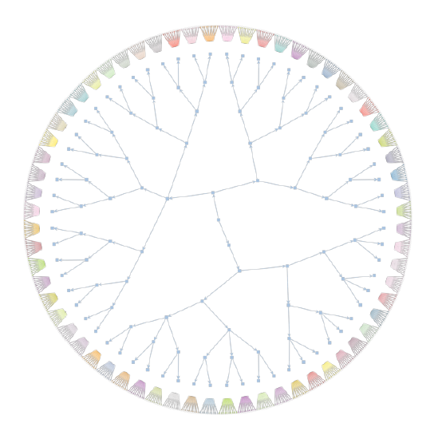

There is no hierarchy here — 64 equal cliques, one flat partition.

Fit a hierarchical model and it reports a hierarchy anyway.

## The hierarchy isn’t unique

Schaub, Li & Peel · *Phys. Rev. E* (2023)

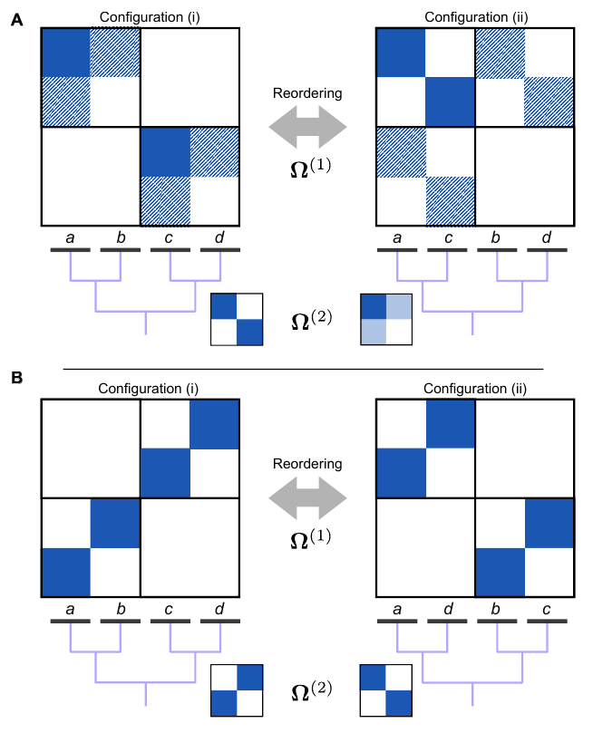

We can define a level precisely — a **stochastic externally equitable partition** — and *even then*, the same finest partition admits different coarsenings.

## Real level, or invented one?

Schaub, Li & Peel · *Phys. Rev. E* (2023)

Perturb the estimated mixing matrix slightly, and re-detect.

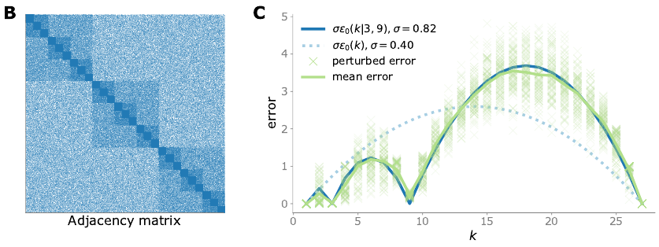

A **genuine** level is stable — the same set of eigenvectors → the same partition re-emerges.

A **spurious** level scatters — degeneracy leads to different eigenvectors → different, partition.

This test identifies the flat hierarchy from before.

## Which partition gets detected?

Peel & Schaub · *Physical Review E* (2024)

[interactive chart not shown]

[figure not shown]

**Take-home 3:** Communities can have communities — but their signals interact across scales, creating new phase transitions.

## When can we reliably know something about network structure?

**①** Are these the communities we are looking for?

**②** When is structure detectable at all?

**③** What if communities have communities?

**④** Does size matter?

**⑤** Does going higher-order actually change anything?

## The standard picture

Detectability thresholds are typically stated for **equal-sized communities** — $k$ groups, uniform connection probabilities.

Two natural recovery notions:

- **Weak recovery** — output correlates with the planted partition better than chance (KS threshold)
- **Exact recovery** — output agrees on all but a vanishing fraction of nodes

The SNR from before generalises. For any SBM with affinity matrix $\Omega$ and group-size matrix $N$, define the **signal matrix** $Q = N\Omega$. Then:

$$\mathrm{SNR} \;=\; \frac{\lambda_2^2}{\lambda_1}$$

where $\lambda_1, \lambda_2$ are the two largest eigenvalues of $Q$. The balanced case recovers $\frac{(d_{\mathrm{in}} - d_{\mathrm{out}})^2}{<d>} > 1$.

However, we don’t expect communities to be all the same size.

## Three phases, not one threshold

Li & Peel · *arXiv* 2604.18565 (2026)

[interactive chart not shown]

## And it holds on generated networks

Li & Peel · *arXiv* 2604.18565 (2026)

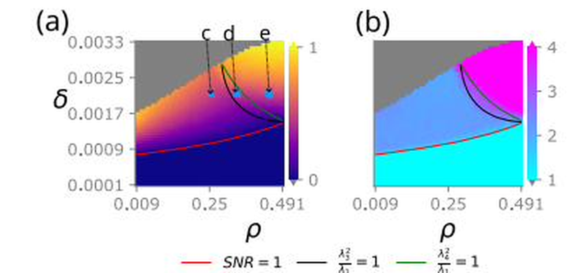

## The same phases, different methods

Li & Peel · *arXiv* 2604.18565 (2026)

Belief propagation and the Bethe Hessian both reach **Kesten–Stigum** for the macroscopic structure.

On the minority structure they **diverge**.

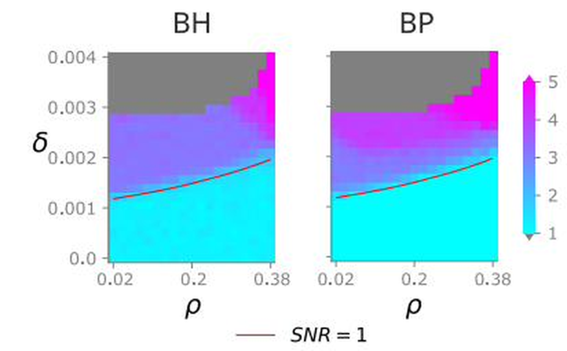

One likely reason: belief propagation can exploit the degree heterogeneity between unequal groups that the linearised spectral method discards.

[figure not shown]

**Take-home 4:** Minority communities have their own detection thresholds — and we can calculate where they are.

## When can we reliably know something about network structure?

**①** Are these the communities we are looking for?

**②** When is structure detectable at all?

**③** What if communities have communities?

**④** Does size matter?

**⑤** Does going higher-order actually change anything?

## Edges are a modelling choice

Peixoto, Peel, Gross & De Domenico · *arXiv* 2602.16937 (2026)

Co-authorship. Group messaging. Metabolic pathways. Neural ensembles.

Many real systems involve **multi-way** interactions — one event binds several nodes at once. The instinct is to reach for a richer object: a **hyperedge**.

Graphs were never confined to two-node interactions. A node’s behaviour can depend on **all** its neighbours at once.

**A hyperedge is a relabelled bipartite edge — it *constrains* a graph, it doesn’t extend one.**

No new expressive power. But the relabelling makes a previously invisible choice *visible*.

## New trade-offs

Li, Schaub & Peel · *arXiv* 2601.10502 (2026)

## Which edges you keep whole sets the answer

Li, Schaub & Peel · *arXiv* 2601.10502 (2026)

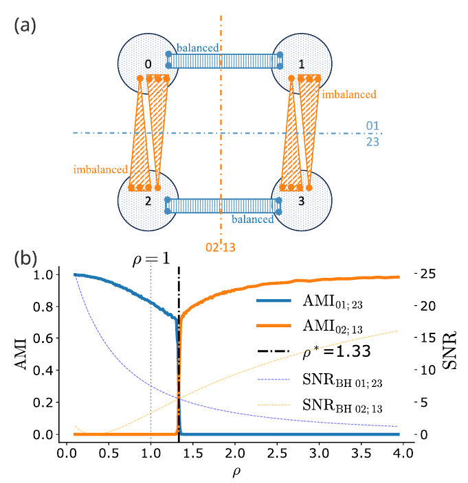

## Spectral clustering lags belief propagation — again

Li, Schaub & Peel · *arXiv* 2601.10502 (2026)

When every edge has the same order, the Bethe Hessian reaches the belief-propagation limit — exactly as in the ordinary-graph case.

Mix the orders, and the Bethe Hessian threshold falls **strictly short** of belief propagation.

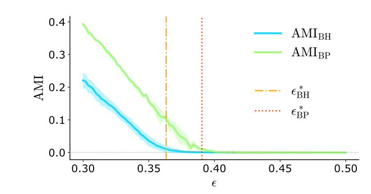

## On real data, the answer changes

Li, Schaub & Peel · *arXiv* 2601.10502 (2026)

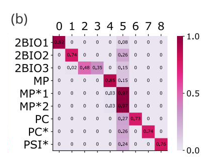